# Supervised Learning Project

Developed By: Olabode James

# Preliminaries

## Project Context:

This case is about a bank (Thera Bank) whose management wants to explore ways of converting its liability customers to personal loan customers (while retaining them as depositors). A campaign that the bank ran last year for liability customers showed a healthy conversion rate of over 9% success. This has encouraged the retail marketing department to devise campaigns with better target marketing to increase the success ratio with a minimal budget.

## Import Libraries

```python
import numpy as np # linear algebra
import pandas as pd
import matplotlib.pyplot as plt       # matplotlib.pyplot plots data

import seaborn as sns
from sklearn.model_selection import train_test_split
from sklearn import metrics
from sklearn.linear_model import LogisticRegression
from sklearn import metrics

sns.set(color_codes=True) # adds a nice background to the graphs

# In order to enable plotting graphs in Jupyter notebook
%matplotlib inline

import statsmodels.api as sm

#AUC ROC curve
from sklearn.metrics import roc_auc_score
from sklearn.metrics import roc_curve
from sklearn.metrics import confusion_matrix, recall_score, precision_score, f1_score, roc_auc_score,accuracy_score

#Need to handle warnings
import warnings
warnings.filterwarnings('ignore')
```

## Load and review data

```python
bankData = pd.read_csv('Bank_Personal_Loan_Modelling.csv')
```

```python
bankData.head()
```

|  | ID | Age | Experience | Income | ZIP Code | Family | CCAvg | Education | Mortgage | Personal Loan | Securities Account | CD Account | Online | CreditCard |
| --- | --- | --- | --- | --- | --- | --- | --- | --- | --- | --- | --- | --- | --- | --- |
| 0 | 1 | 25 | 1 | 49 | 91107 | 4 | 1.6 | 1 | 0 | 0 | 1 | 0 | 0 | 0 |
| 1 | 2 | 45 | 19 | 34 | 90089 | 3 | 1.5 | 1 | 0 | 0 | 1 | 0 | 0 | 0 |
| 2 | 3 | 39 | 15 | 11 | 94720 | 1 | 1.0 | 1 | 0 | 0 | 0 | 0 | 0 | 0 |
| 3 | 4 | 35 | 9 | 100 | 94112 | 1 | 2.7 | 2 | 0 | 0 | 0 | 0 | 0 | 0 |
| 4 | 5 | 35 | 8 | 45 | 91330 | 4 | 1.0 | 2 | 0 | 0 | 0 | 0 | 0 | 1 |

# Project Deliverables

## Task 1: Import the datasets and libraries, check datatype, statistical summary, shape, null values or incorrect imputation. (5 marks)

```python
# Here we check the datatypes in our dataset
bankData.dtypes
```

```
ID                      int64
Age                     int64
Experience              int64
Income                  int64
ZIP Code                int64
Family                  int64
CCAvg                 float64
Education               int64
Mortgage                int64
Personal Loan           int64
Securities Account      int64
CD Account              int64
Online                  int64
CreditCard              int64
dtype: object
```

```python
# Here we do statistical summary
bankData.describe().transpose()
```

|  | count | mean | std | min | 25% | 50% | 75% | max |
| --- | --- | --- | --- | --- | --- | --- | --- | --- |
| ID | 5000.0 | 2500.500000 | 1443.520003 | 1.0 | 1250.75 | 2500.5 | 3750.25 | 5000.0 |
| Age | 5000.0 | 45.338400 | 11.463166 | 23.0 | 35.00 | 45.0 | 55.00 | 67.0 |
| Experience | 5000.0 | 20.104600 | 11.467954 | -3.0 | 10.00 | 20.0 | 30.00 | 43.0 |
| Income | 5000.0 | 73.774200 | 46.033729 | 8.0 | 39.00 | 64.0 | 98.00 | 224.0 |
| ZIP Code | 5000.0 | 93152.503000 | 2121.852197 | 9307.0 | 91911.00 | 93437.0 | 94608.00 | 96651.0 |
| Family | 5000.0 | 2.396400 | 1.147663 | 1.0 | 1.00 | 2.0 | 3.00 | 4.0 |
| CCAvg | 5000.0 | 1.937938 | 1.747659 | 0.0 | 0.70 | 1.5 | 2.50 | 10.0 |
| Education | 5000.0 | 1.881000 | 0.839869 | 1.0 | 1.00 | 2.0 | 3.00 | 3.0 |
| Mortgage | 5000.0 | 56.498800 | 101.713802 | 0.0 | 0.00 | 0.0 | 101.00 | 635.0 |
| Personal Loan | 5000.0 | 0.096000 | 0.294621 | 0.0 | 0.00 | 0.0 | 0.00 | 1.0 |
| Securities Account | 5000.0 | 0.104400 | 0.305809 | 0.0 | 0.00 | 0.0 | 0.00 | 1.0 |
| CD Account | 5000.0 | 0.060400 | 0.238250 | 0.0 | 0.00 | 0.0 | 0.00 | 1.0 |
| Online | 5000.0 | 0.596800 | 0.490589 | 0.0 | 0.00 | 1.0 | 1.00 | 1.0 |
| CreditCard | 5000.0 | 0.294000 | 0.455637 | 0.0 | 0.00 | 0.0 | 1.00 | 1.0 |

```python
#Here we check the shape of our data
bankData.shape
```

```
(5000, 14)
```

```python
#Here we check for null entry in our dataset
bankData.isnull().any()
```

```
ID                    False
Age                   False
Experience            False
Income                False
ZIP Code              False
Family                False
CCAvg                 False
Education             False
Mortgage              False
Personal Loan         False
Securities Account    False
CD Account            False
Online                False
CreditCard            False
dtype: bool
```

```python
#Wrong Imputations: Here we check if non-numbers/numeric/real has been entered in any of the numerical columns
bankData.applymap(np.isreal).any()
```

```
ID                    True
Age                   True
Experience            True
Income                True
ZIP Code              True
Family                True
CCAvg                 True
Education             True
Mortgage              True
Personal Loan         True
Securities Account    True
CD Account            True
Online                True
CreditCard            True
dtype: bool
```

## Task 2: EDA: Study the data distribution in each attribute and target variable, share your findings (20 marks)

### a. Number of unique in each column?

```python
bankData.nunique()
```

```
ID                    5000
Age                     45
Experience              47
Income                 162
ZIP Code               467
Family                   4
CCAvg                  108
Education                3
Mortgage               347
Personal Loan            2
Securities Account       2
CD Account               2
Online                   2
CreditCard               2
dtype: int64
```

### b. Number of people with zero mortgage?

```python
#(bankData['Mortgage'] == 0).value_counts(normalize=True)

zeroMortgagePeople = len(bankData.loc[bankData['Mortgage'] == 0])
print("Number of people with zero Mortgage:", zeroMortgagePeople)
```

```
Number of people with zero Mortgage: 3462
```

### c. Number of people with zero credit card spending per month?

```python
#We can make this more explicit by grouping based on people with or without credit card, and then map amount spent
# Reason is to ensure we separate individuals with credit cards but not incuring expenses therewith(not using)
bankData.groupby(['CreditCard', 'CCAvg'])['CCAvg'].count()


#I need to check this against the overall dataset
zeroCreditCardPeople = len(bankData.loc[bankData['CCAvg'] == 0.0])
print("Total Number of people with zero credit card spending per month:", zeroCreditCardPeople)
#bankData.loc[bankData['CCAvg'] == 0.0]
```

```
Total Number of people with zero credit card spending per month: 106
```

### d. Value counts of all categorical columns.

```python
#We have 7 categorical columns in our dataset
#I can use groupby to achieve this, as I believe outputing just numbers is not all expected

#First Cat Column - Family
bankData.groupby('Family')['Family'].count()
```

```
Family
1    1472
2    1296
3    1010
4    1222
Name: Family, dtype: int64
```

```python
#Second Cat Column - Education - Educational Level
bankData.groupby('Education')['Education'].count()
```

```
Education
1    2096
2    1403
3    1501
Name: Education, dtype: int64
```

```python
#Third Cat Column - Personal Loan - Yes or No
bankData.groupby('Personal Loan')['Personal Loan'].count()
#bankData['Personal Loan'].value_counts()
```

```
Personal Loan
0    4520
1     480
Name: Personal Loan, dtype: int64
```

```python
#This will help me examine the fact in the problem statement, in which 9.6% only took personal loan the last time
bankData['Personal Loan'].value_counts(normalize=True)
```

```
0    0.904
1    0.096
Name: Personal Loan, dtype: float64
```

DEDUCTION: The problem statement is accurate is stating 9.6% success in the last campaign on personal loan

```python
#Fourth Cat Column - Securities Account - Yes or No
bankData.groupby('Securities Account')['Securities Account'].count()
```

```
Securities Account
0    4478
1     522
Name: Securities Account, dtype: int64
```

```python
#Fifth Cat Column - CD Account - Yes or No
bankData.groupby('CD Account')['CD Account'].count()
```

```
CD Account
0    4698
1     302
Name: CD Account, dtype: int64
```

```python
#Sixth Cat Column - Online - Yes or No
bankData.groupby('Online')['Online'].count()
```

```
Online
0    2016
1    2984
Name: Online, dtype: int64
```

```python
#Seventh Cat Column - CreditCard - Yes or No
bankData.groupby('CreditCard')['CreditCard'].count()
#bankData['CreditCard'].value_counts()
```

```
CreditCard
0    3530
1    1470
Name: CreditCard, dtype: int64
```

### e. Univariate and Bivariate

```python
# The following code plots a histrogram using the matplotlib package.
# We need to create dataset for columns which will fit the profile for univariate analysis - Continuous variable columns is the first hint here
# Narrowing down variables for Univariate Analysis - Age, Mortgage, CCAvg spend and Income are factors
# Likely to affect interest in taking up extra liabilities in the form of personal loan
ageAnalysis = bankData['Age']
mortgageAnalysis = bankData['Mortgage']
ccardAnalysis = bankData['CCAvg']
incomeAnalysis = bankData['Income']
loanAnalysis = bankData['Personal Loan']
```

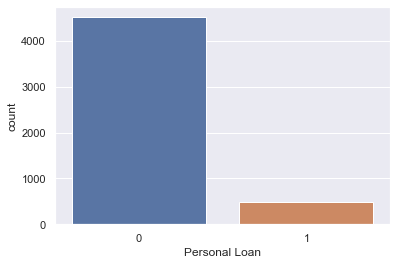

```python
#Checking Age Distribution For our bank's current depositors dataset
sns.countplot(loanAnalysis);
```

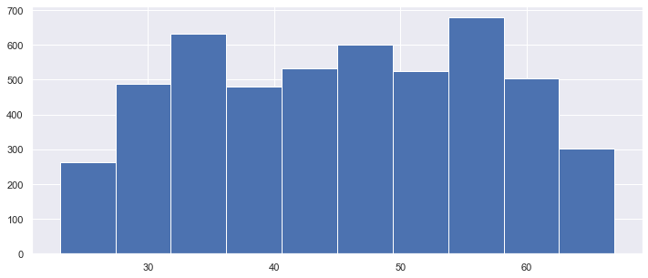

```python
#Checking Age Distribution For our bank's current depositors dataset
plt.figure(figsize=(12,5))
plt.hist(ageAnalysis);
```

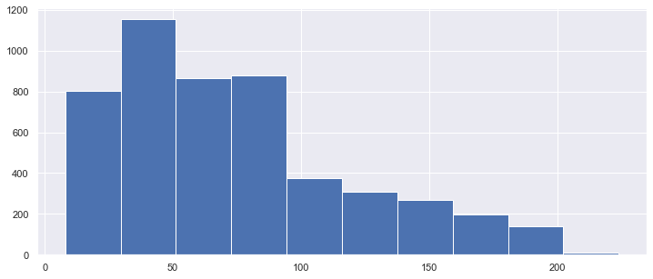

```python
#Checking Income Distribution For our bank's current depositors dataset
plt.figure(figsize=(12,5))
plt.hist(incomeAnalysis);
```

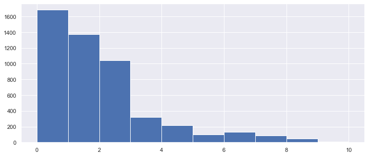

```python
#Checking Credit Card Monthly Spend Distribution For our bank's current depositors dataset
plt.figure(figsize=(12,5))
plt.hist(ccardAnalysis);
```

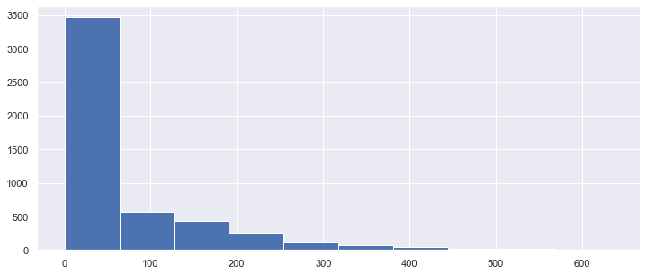

```python
#Checking Income Distribution For our bank's current depositors dataset
plt.figure(figsize=(12,5))
plt.hist(mortgageAnalysis);
```

```python
#Bivariate Plot
#Since the ID column will not be relevant for our analysis, we can drop it
bankDataRev = bankData.drop(['ID'], axis=1)
```

```python
#As our interest is in subscription for personal loan, can we do bivariate plot to check relationship
#between certain independent variable and personal loans
#perhaps we will be able to gather some (business)insights which will be useful
#Selected independent variables will be of interest here
#Here: Age, Income, Experience, Family, CCAvg, Education, Mortgage, Securities Account, CD Account, Online, Credit Card
```

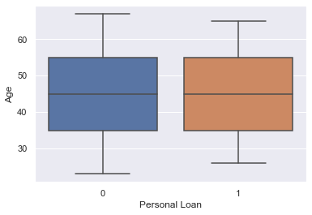

```python
sns.boxplot(bankDataRev['Personal Loan'], bankDataRev['Age']);
```

INSIGHT: The median Age for those with or without personal loan is almost same, so we cannot say Age has strong influence on if a customer will take personal loan or not

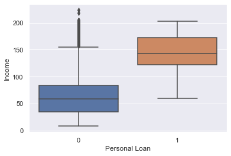

```python
sns.boxplot(bankDataRev['Personal Loan'], bankDataRev['Income']);
```

INSIGHT: Strong insight here, median Income for those taking personal loan is 140k, while those not taking is 60k. The higher the income, the higher the tendency to take personal loan

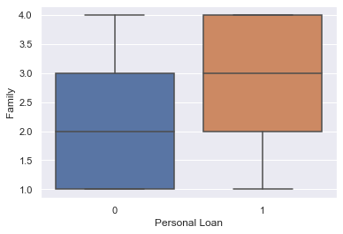

```python
sns.boxplot(bankDataRev['Personal Loan'], bankDataRev['Family']);
```

INSIGHT: Personal loan customers tend to have large family - good insight herewith

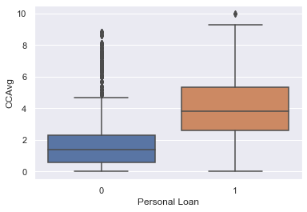

```python
sns.boxplot(bankDataRev['Personal Loan'], bankDataRev['CCAvg']);
```

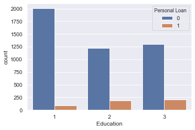

```python
sns.countplot(bankDataRev['Education'], hue=bankDataRev['Personal Loan']);
```

INSIGHT: Customer with Graduate or Professional/Advanced Educational Level show better chances of taking personal loan

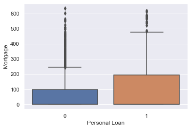

```python
sns.boxplot(bankDataRev['Personal Loan'], bankDataRev['Mortgage']);
```

INSIGHT: The Upper Whiskers(1.5IQR) for Personal Loan customer is way higher than that for non-personal loan customers. Personal loan customers tend to have higher mortgage than non-personal loan customer. Good insight here

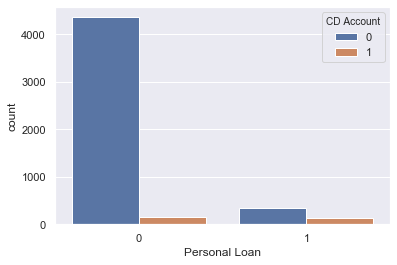

```python
sns.countplot(bankDataRev['Personal Loan'], hue=bankDataRev['CD Account']);
```

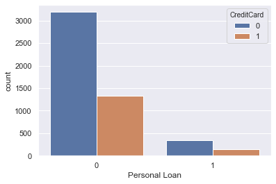

```python
sns.countplot(bankDataRev['Personal Loan'], hue=bankDataRev['CreditCard']);
```

INSIGHT: Personal Loan tend to be proportionate between credit card and none credit card customers - thus we cannot use this as a strong criteria

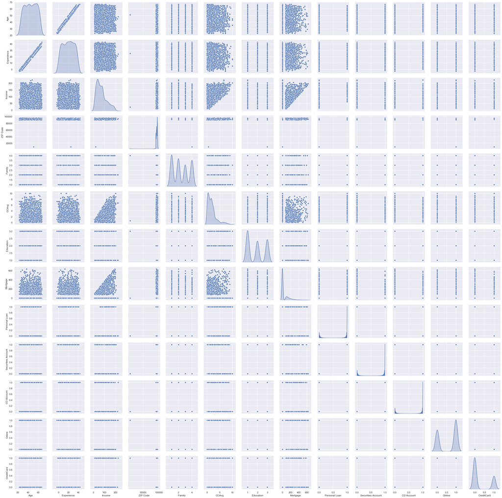

```python
sns.pairplot(bankDataRev,diag_kind='kde');
```

```python
bankDataRev.corr()
```

|  | Age | Experience | Income | ZIP Code | Family | CCAvg | Education | Mortgage | Personal Loan | Securities Account | CD Account | Online | CreditCard |
| --- | --- | --- | --- | --- | --- | --- | --- | --- | --- | --- | --- | --- | --- |
| Age | 1.000000 | 0.994215 | -0.055269 | -0.029216 | -0.046418 | -0.052012 | 0.041334 | -0.012539 | -0.007726 | -0.000436 | 0.008043 | 0.013702 | 0.007681 |
| Experience | 0.994215 | 1.000000 | -0.046574 | -0.028626 | -0.052563 | -0.050077 | 0.013152 | -0.010582 | -0.007413 | -0.001232 | 0.010353 | 0.013898 | 0.008967 |
| Income | -0.055269 | -0.046574 | 1.000000 | -0.016410 | -0.157501 | 0.645984 | -0.187524 | 0.206806 | 0.502462 | -0.002616 | 0.169738 | 0.014206 | -0.002385 |
| ZIP Code | -0.029216 | -0.028626 | -0.016410 | 1.000000 | 0.011778 | -0.004061 | -0.017377 | 0.007383 | 0.000107 | 0.004704 | 0.019972 | 0.016990 | 0.007691 |
| Family | -0.046418 | -0.052563 | -0.157501 | 0.011778 | 1.000000 | -0.109275 | 0.064929 | -0.020445 | 0.061367 | 0.019994 | 0.014110 | 0.010354 | 0.011588 |
| CCAvg | -0.052012 | -0.050077 | 0.645984 | -0.004061 | -0.109275 | 1.000000 | -0.136124 | 0.109905 | 0.366889 | 0.015086 | 0.136534 | -0.003611 | -0.006689 |
| Education | 0.041334 | 0.013152 | -0.187524 | -0.017377 | 0.064929 | -0.136124 | 1.000000 | -0.033327 | 0.136722 | -0.010812 | 0.013934 | -0.015004 | -0.011014 |
| Mortgage | -0.012539 | -0.010582 | 0.206806 | 0.007383 | -0.020445 | 0.109905 | -0.033327 | 1.000000 | 0.142095 | -0.005411 | 0.089311 | -0.005995 | -0.007231 |
| Personal Loan | -0.007726 | -0.007413 | 0.502462 | 0.000107 | 0.061367 | 0.366889 | 0.136722 | 0.142095 | 1.000000 | 0.021954 | 0.316355 | 0.006278 | 0.002802 |
| Securities Account | -0.000436 | -0.001232 | -0.002616 | 0.004704 | 0.019994 | 0.015086 | -0.010812 | -0.005411 | 0.021954 | 1.000000 | 0.317034 | 0.012627 | -0.015028 |
| CD Account | 0.008043 | 0.010353 | 0.169738 | 0.019972 | 0.014110 | 0.136534 | 0.013934 | 0.089311 | 0.316355 | 0.317034 | 1.000000 | 0.175880 | 0.278644 |
| Online | 0.013702 | 0.013898 | 0.014206 | 0.016990 | 0.010354 | -0.003611 | -0.015004 | -0.005995 | 0.006278 | 0.012627 | 0.175880 | 1.000000 | 0.004210 |
| CreditCard | 0.007681 | 0.008967 | -0.002385 | 0.007691 | 0.011588 | -0.006689 | -0.011014 | -0.007231 | 0.002802 | -0.015028 | 0.278644 | 0.004210 | 1.000000 |